# Palmer Penguins

### Inspired by Julia Silge

For this week's #TidyTuesday dataset, we'll be looking at [palmerpenguins] (https://allisonhorst.github.io/palmerpenguins/), Antarctic penguins who live on the Palmer Archipelago. More details on this dataset can be found on the [RStudio Education blog] (https://education.rstudio.com/blog/2020/07/palmerpenguins-cran/). We would like to come up with a model that predicts the [sex of the penguins] (https://github.com/rfordatascience/tidytuesday/blob/master/data/2020/2020-07-28/readme.md) using a classification model, based on the other observations in the dataset i.e. supervised learning. Let's now load the dataset from `palmerpenguins` package.

```r
library(tidyverse)
library(palmerpenguins)

penguins
```

```
## # A tibble: 344 x 8
##    species island bill_length_mm bill_depth_mm flipper_length_… body_mass_g
##    <fct>   <fct>           <dbl>         <dbl>            <int>       <int>
##  1 Adelie  Torge…           39.1          18.7              181        3750
##  2 Adelie  Torge…           39.5          17.4              186        3800
##  3 Adelie  Torge…           40.3          18                195        3250
##  4 Adelie  Torge…           NA            NA                 NA          NA
##  5 Adelie  Torge…           36.7          19.3              193        3450
##  6 Adelie  Torge…           39.3          20.6              190        3650
##  7 Adelie  Torge…           38.9          17.8              181        3625
##  8 Adelie  Torge…           39.2          19.6              195        4675
##  9 Adelie  Torge…           34.1          18.1              193        3475
## 10 Adelie  Torge…           42            20.2              190        4250
## # … with 334 more rows, and 2 more variables: sex <fct>, year <int>
```

## Data Exploration

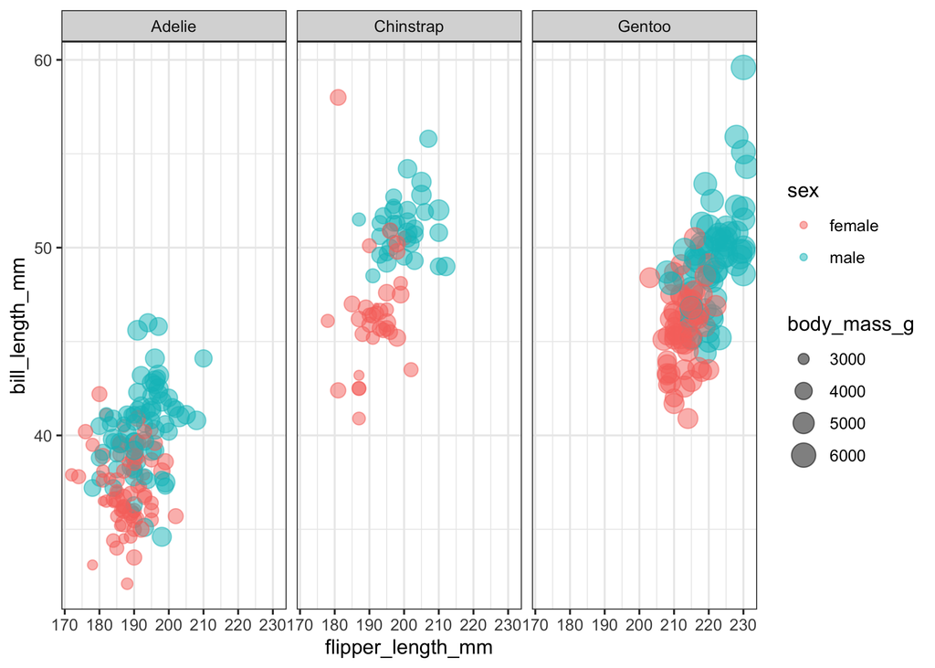

```r
penguins %>%
  filter(!is.na(sex)) %>%
  ggplot(aes(flipper_length_mm, bill_length_mm, color = sex, size = body_mass_g)) +
  geom_point(alpha = 0.5) +
  facet_wrap(~species) +
  theme_bw()
```

- Generally, female penguins are lighter.

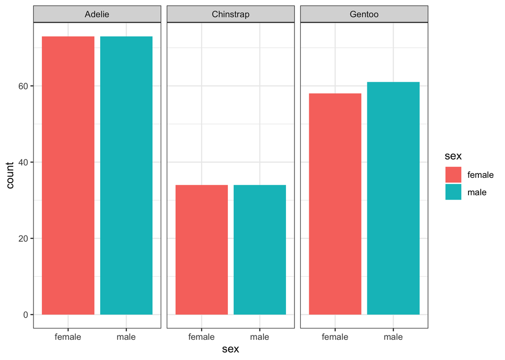

```r
penguins %>%
  filter(!is.na(sex)) %>%
  ggplot(aes(sex, fill = sex)) +
  geom_bar() +
  facet_wrap(~species) +
  theme_bw()
```

- We have almost equal number of female and male birds for each species.

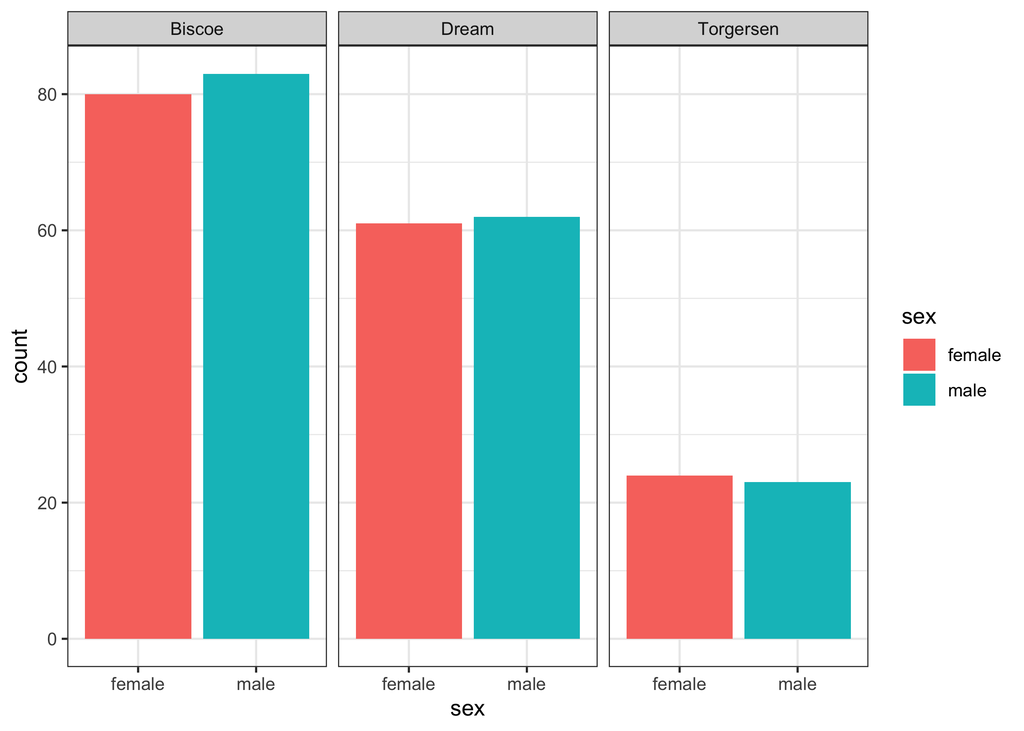

```r
penguins %>%
  filter(!is.na(sex)) %>%
  ggplot(aes(sex, fill = sex)) +
  geom_bar() +
  facet_wrap(~island) +
  theme_bw()
```

- Again, the distribution of sexes is quite uniform for different islands.

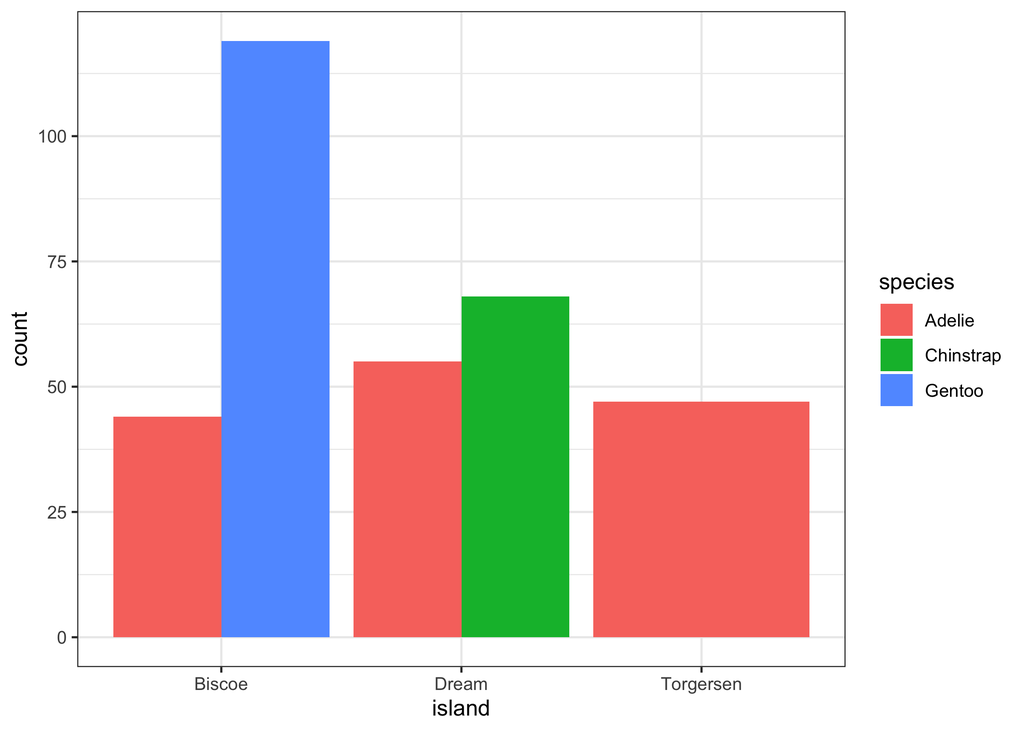

```r
penguins %>%
  filter(!is.na(sex)) %>%
  ggplot(aes(island, fill = species)) +
  geom_bar(position = 'dodge') +
  theme_bw()
```

- Not all species are present in every island. We may then not include any modeling that tries to find the relationship between these two.

For the preliminary modeling, we will not use year and island.

```r
penguins_df <-
  penguins %>%
  filter(!is.na(sex)) %>%
  select(-year, -island)
```

## Build a model

Firstly, we need to split our data into training and test sets.

```r
library(tidymodels)
set.seed(123)
penguin_split <- initial_split(penguins_df, strata = sex)
penguin_train <- training(penguin_split)
penguin_test <- testing(penguin_split)
```

Secondly, we create bootstrap resamples of the training data for model evaluation.

```r
set.seed(123)
penguin_bs <- bootstraps(penguin_train)
penguin_bs
```

```
## # Bootstrap sampling
## # A tibble: 25 x 2
##    splits            id
##    <list>            <chr>
##  1 <split [250/87]>  Bootstrap01
##  2 <split [250/82]>  Bootstrap02
##  3 <split [250/95]>  Bootstrap03
##  4 <split [250/88]>  Bootstrap04
##  5 <split [250/92]>  Bootstrap05
##  6 <split [250/93]>  Bootstrap06
##  7 <split [250/101]> Bootstrap07
##  8 <split [250/91]>  Bootstrap08
##  9 <split [250/101]> Bootstrap09
## 10 <split [250/85]>  Bootstrap10
## # … with 15 more rows
```

For this analysis, we will be comparing 2 different models: *logistic regression* and *random forest*. Let's create the model specifications.

```r
glm_spec <- logistic_reg() %>%
  set_engine("glm")

glm_spec
```

```
## Logistic Regression Model Specification (classification)
##
## Computational engine: glm
```

```r
rf_spec <- rand_forest() %>%
  set_mode("classification") %>%
  set_engine("ranger")

rf_spec
```

```
## Random Forest Model Specification (classification)
##
## Computational engine: ranger
```

Fourthly, we'll create `workflow()` for our models, which is a helper object to manage modeling pipelines with pieces that fit together like Lego blocks.

```r
penguin_wf <- workflow() %>%
  add_formula(sex ~.)
penguin_wf
```

```
## ══ Workflow ═════════════════════════════════════════════════════════════════════════════════════════
## Preprocessor: Formula
## Model: None
##
## ── Preprocessor ─────────────────────────────────────────────────────────────────────────────────────
## sex ~ .
```

Next, we'll add the models into the `penguin_wf` and then fit to each of the resamples. Let's start with the *logistic regression* model first.

```r
glm_rs <- penguin_wf %>%
  add_model(glm_spec) %>%
  fit_resamples(
    resamples = penguin_bs,
    control = control_resamples(save_pred = TRUE)
  )

glm_rs
```

```
## # Bootstrap sampling
## # A tibble: 25 x 5
##    splits           id          .metrics        .notes         .predictions
##    <list>           <chr>       <list>          <list>         <list>
##  1 <split [250/87]> Bootstrap01 <tibble [2 × 3… <tibble [1 × … <tibble [87 × 5]>
##  2 <split [250/82]> Bootstrap02 <tibble [2 × 3… <tibble [1 × … <tibble [82 × 5]>
##  3 <split [250/95]> Bootstrap03 <tibble [2 × 3… <tibble [1 × … <tibble [95 × 5]>
##  4 <split [250/88]> Bootstrap04 <tibble [2 × 3… <tibble [1 × … <tibble [88 × 5]>
##  5 <split [250/92]> Bootstrap05 <tibble [2 × 3… <tibble [1 × … <tibble [92 × 5]>
##  6 <split [250/93]> Bootstrap06 <tibble [2 × 3… <tibble [1 × … <tibble [93 × 5]>
##  7 <split [250/101… Bootstrap07 <tibble [2 × 3… <tibble [1 × … <tibble [101 × 5…
##  8 <split [250/91]> Bootstrap08 <tibble [2 × 3… <tibble [1 × … <tibble [91 × 5]>
##  9 <split [250/101… Bootstrap09 <tibble [2 × 3… <tibble [1 × … <tibble [101 × 5…
## 10 <split [250/85]> Bootstrap10 <tibble [2 × 3… <tibble [1 × … <tibble [85 × 5]>
## # … with 15 more rows
```

Now, we can fit the *random forest* model.

```r
rf_rs <- penguin_wf %>%
  add_model(rf_spec) %>%
  fit_resamples(
    resamples = penguin_bs,
    control = control_resamples(save_pred = TRUE)
  )

rf_rs
```

```
## # Bootstrap sampling
## # A tibble: 25 x 5
##    splits           id          .metrics        .notes         .predictions
##    <list>           <chr>       <list>          <list>         <list>
##  1 <split [250/87]> Bootstrap01 <tibble [2 × 3… <tibble [0 × … <tibble [87 × 5]>
##  2 <split [250/82]> Bootstrap02 <tibble [2 × 3… <tibble [0 × … <tibble [82 × 5]>
##  3 <split [250/95]> Bootstrap03 <tibble [2 × 3… <tibble [0 × … <tibble [95 × 5]>
##  4 <split [250/88]> Bootstrap04 <tibble [2 × 3… <tibble [0 × … <tibble [88 × 5]>
##  5 <split [250/92]> Bootstrap05 <tibble [2 × 3… <tibble [0 × … <tibble [92 × 5]>
##  6 <split [250/93]> Bootstrap06 <tibble [2 × 3… <tibble [0 × … <tibble [93 × 5]>
##  7 <split [250/101… Bootstrap07 <tibble [2 × 3… <tibble [0 × … <tibble [101 × 5…
##  8 <split [250/91]> Bootstrap08 <tibble [2 × 3… <tibble [0 × … <tibble [91 × 5]>
##  9 <split [250/101… Bootstrap09 <tibble [2 × 3… <tibble [0 × … <tibble [101 × 5…
## 10 <split [250/85]> Bootstrap10 <tibble [2 × 3… <tibble [0 × … <tibble [85 × 5]>
## # … with 15 more rows
```

We can then proceed to evaluate these 2 models and pick the better one.

## Model Evaluation

For *logistic regression*,

```r
collect_metrics(glm_rs)
```

```
## # A tibble: 2 x 5
##   .metric  .estimator  mean     n std_err
##   <chr>    <chr>      <dbl> <int>   <dbl>
## 1 accuracy binary     0.895    25 0.00447
## 2 roc_auc  binary     0.969    25 0.00227
```

For *random forest*,

```r
collect_metrics(rf_rs)
```

```
## # A tibble: 2 x 5
##   .metric  .estimator  mean     n std_err
##   <chr>    <chr>      <dbl> <int>   <dbl>
## 1 accuracy binary     0.889    25 0.00604
## 2 roc_auc  binary     0.960    25 0.00252
```

As we can observe, both models work pretty good with high **accuracy** and **roc_auc**. To proceed, we can apply as a general rule of thumb: if a more complex model performs similary to a simpler model, pick the simpler model. Thus, we will choose *logistic regression*. Let's plot an ROC curve.

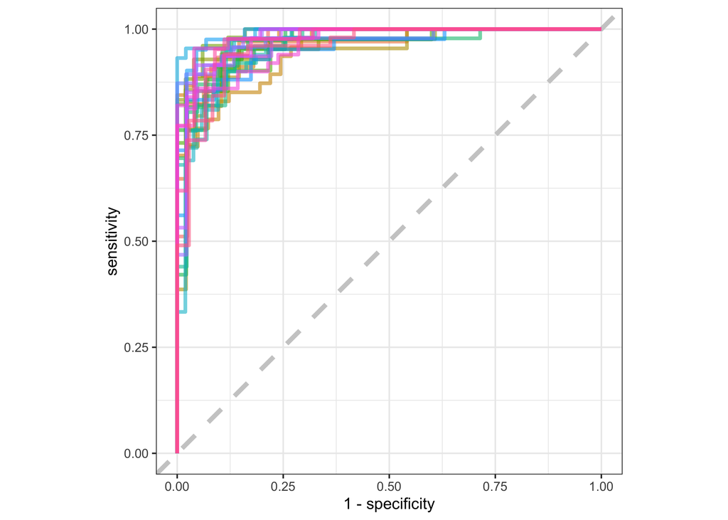

```r
glm_rs %>%
  collect_predictions() %>%
  group_by(id) %>%
  roc_curve(sex, .pred_female) %>%
  ggplot(aes(1 - specificity, sensitivity, color = id)) +
  geom_abline(lty = 2, color = 'gray80', size = 1.5) +
  geom_path(show.legend = FALSE, alpha = 0.6, size = 1.2) +
  coord_equal() +
  theme_bw()
```

Notive that this ROC curve is more jagged than common ones because the small size of our dataset.

Let's now evaluate using our testing set with fitting one last time the model to the training data using the function `last_fit()`.

```r
penguin_final <- penguin_wf %>%
  add_model(glm_spec) %>%
  last_fit(penguin_split)
penguin_final
```

```
## # Monte Carlo cross-validation (0.75/0.25) with 1 resamples
## # A tibble: 1 x 6
##   splits       id           .metrics      .notes       .predictions    .workflow
##   <list>       <chr>        <list>        <list>       <list>          <list>
## 1 <split [250… train/test … <tibble [2 ×… <tibble [1 … <tibble [83 × … <workflo…
```

Let's look at the results

```r
collect_metrics(penguin_final)
```

```
## # A tibble: 2 x 3
##   .metric  .estimator .estimate
##   <chr>    <chr>          <dbl>
## 1 accuracy binary         0.952
## 2 roc_auc  binary         0.984
```

```r
collect_predictions(penguin_final) %>%
  conf_mat(sex, .pred_class)
```

```
##           Truth
## Prediction female male
##     female     40    3
##     male        1   39
```